# Predicting [fraudulent healthcare providers](https://www.kaggle.com/datasets/rohitrox/healthcare-provider-fraud-detection-analysis/data)

Fraudulent providers may

1. Bill for services that they did not provided
2. Submit the same claim multiple times
3. Misrepresent the details of the services provided
4. Charge for more complex/expensive services than provided
5. Bill for a different service when the provided services were not covered

## This dataset contain 3 components

1. **Inpatient data**, which contain the claims filed for admitted patients
2. **Outpatient data**, which contain the claims filed for outpatients
3. **Beneficiary data**, which contain the details such as health conditions, geographic regions, etc.

## Notice the key modules of `sklearn` that we need to import each function from

`sklearn.linear_model` and `sklearn.ensemble` for the models

`sklearn.preprocessing` for preprocessing tools

`sklearn.model_selection` for tools that can help us select the best model (data splitting, hyperparameter tuning)

`sklearn.feature_selection` for tools that can help us select the best feature set

`sklearn.metrics` for performance metrics

```python
import numpy as np
import pandas as pd
import matplotlib.pyplot as plt
import seaborn as sns

from zipfile import ZipFile
from datetime import date, timedelta

from scipy.stats import fisher_exact

from sklearn.linear_model import LogisticRegression
from sklearn.ensemble import RandomForestClassifier

from sklearn.preprocessing import StandardScaler
from sklearn.model_selection import train_test_split, StratifiedKFold, GridSearchCV
from sklearn.feature_selection import RFECV

from sklearn.metrics import accuracy_score, roc_auc_score, average_precision_score, f1_score
from sklearn.metrics import confusion_matrix, classification_report
from sklearn.metrics import roc_curve, precision_recall_curve

from sklearn.base import clone
```

## Load data from multiple files within a zip file

The csv files are zipped, so we use `zipfile.ZipFile()` to access them

Pandas `read_csv()` can receive the opened `ZipFile()` object as input

```python
all_df = {}

with ZipFile('datasets/Kaggle_healthcare_fraud.zip', 'r') as zin:
    for f in zin.namelist():
        if f.startswith('Train'):
            if '_' in f: ## input data
                table_name = f.split('-')[0].split('_')[1]
            else: ## label
                table_name = 'Label'

            if table_name in ['Inpatientdata', 'Outpatientdata']:
                all_df[table_name] = pd.read_csv(zin.open(f), header = 0, index_col = 1)
            else:
                all_df[table_name] = pd.read_csv(zin.open(f), header = 0, index_col = 0)
```

```python
for table_name in all_df:
    print(table_name, all_df[table_name].shape)
```

```
Label (5410, 1)
Beneficiarydata (138556, 24)
Inpatientdata (40474, 29)
Outpatientdata (517737, 26)
```

### Explore ID system

1. Provider ID, with fraudulent label
2. Beneficiary ID for each patient
3. Claim ID
4. Physician ID

The same beneficiary ID can appear in multiple claims

```python
for table_name in all_df:
    display(all_df[table_name].head(2))
```

| Provider | PotentialFraud |
| --- | --- |
| PRV51001 | No |
| PRV51003 | Yes |

| BeneID | DOB | DOD | Gender | Race | RenalDiseaseIndicator | State | County | NoOfMonths_PartACov | NoOfMonths_PartBCov | ChronicCond_Alzheimer | ... | ChronicCond_Depression | ChronicCond_Diabetes | ChronicCond_IschemicHeart | ChronicCond_Osteoporasis | ChronicCond_rheumatoidarthritis | ChronicCond_stroke | IPAnnualReimbursementAmt | IPAnnualDeductibleAmt | OPAnnualReimbursementAmt | OPAnnualDeductibleAmt |
| --- | --- | --- | --- | --- | --- | --- | --- | --- | --- | --- | --- | --- | --- | --- | --- | --- | --- | --- | --- | --- | --- |
| BENE11001 | 1943-01-01 | NaN | 1 | 1 | 0 | 39 | 230 | 12 | 12 | 1 | ... | 1 | 1 | 1 | 2 | 1 | 1 | 36000 | 3204 | 60 | 70 |
| BENE11002 | 1936-09-01 | NaN | 2 | 1 | 0 | 39 | 280 | 12 | 12 | 2 | ... | 2 | 2 | 2 | 2 | 2 | 2 | 0 | 0 | 30 | 50 |

2 rows × 24 columns

| ClaimID | BeneID | ClaimStartDt | ClaimEndDt | Provider | InscClaimAmtReimbursed | AttendingPhysician | OperatingPhysician | OtherPhysician | AdmissionDt | ClmAdmitDiagnosisCode | ... | ClmDiagnosisCode_7 | ClmDiagnosisCode_8 | ClmDiagnosisCode_9 | ClmDiagnosisCode_10 | ClmProcedureCode_1 | ClmProcedureCode_2 | ClmProcedureCode_3 | ClmProcedureCode_4 | ClmProcedureCode_5 | ClmProcedureCode_6 |
| --- | --- | --- | --- | --- | --- | --- | --- | --- | --- | --- | --- | --- | --- | --- | --- | --- | --- | --- | --- | --- | --- |
| CLM46614 | BENE11001 | 2009-04-12 | 2009-04-18 | PRV55912 | 26000 | PHY390922 | NaN | NaN | 2009-04-12 | 7866 | ... | 2724 | 19889 | 5849 | NaN | NaN | NaN | NaN | NaN | NaN | NaN |
| CLM66048 | BENE11001 | 2009-08-31 | 2009-09-02 | PRV55907 | 5000 | PHY318495 | PHY318495 | NaN | 2009-08-31 | 6186 | ... | NaN | NaN | NaN | NaN | 7092.0 | NaN | NaN | NaN | NaN | NaN |

2 rows × 29 columns

| ClaimID | BeneID | ClaimStartDt | ClaimEndDt | Provider | InscClaimAmtReimbursed | AttendingPhysician | OperatingPhysician | OtherPhysician | ClmDiagnosisCode_1 | ClmDiagnosisCode_2 | ... | ClmDiagnosisCode_9 | ClmDiagnosisCode_10 | ClmProcedureCode_1 | ClmProcedureCode_2 | ClmProcedureCode_3 | ClmProcedureCode_4 | ClmProcedureCode_5 | ClmProcedureCode_6 | DeductibleAmtPaid | ClmAdmitDiagnosisCode |
| --- | --- | --- | --- | --- | --- | --- | --- | --- | --- | --- | --- | --- | --- | --- | --- | --- | --- | --- | --- | --- | --- |
| CLM624349 | BENE11002 | 2009-10-11 | 2009-10-11 | PRV56011 | 30 | PHY326117 | NaN | NaN | 78943 | V5866 | ... | NaN | NaN | NaN | NaN | NaN | NaN | NaN | NaN | 0 | 56409 |
| CLM189947 | BENE11003 | 2009-02-12 | 2009-02-12 | PRV57610 | 80 | PHY362868 | NaN | NaN | 6115 | NaN | ... | NaN | NaN | NaN | NaN | NaN | NaN | NaN | NaN | 0 | 79380 |

2 rows × 26 columns

## Some QC

There should be no duplicated claim ID

```python
number_unique_claim = set(all_df['Inpatientdata'].index).union(all_df['Outpatientdata'].index)

print(len(number_unique_claim))
print(all_df['Inpatientdata'].shape[0] + all_df['Outpatientdata'].shape[0])
```

```
558211
558211
```

Did the beneficiary table contain information for every patient in the claim tables?

```python
print(all_df['Inpatientdata'].shape[0], len(all_df['Inpatientdata']['BeneID'].isin(all_df['Beneficiarydata'].index)))
print(all_df['Outpatientdata'].shape[0], len(all_df['Outpatientdata']['BeneID'].isin(all_df['Beneficiarydata'].index)))
```

```
40474 40474
517737 517737
```

Do the inpatient and outpatient tables contain the same features?

```python
print('inpatient:', all_df['Inpatientdata'].shape[1])
print('outpatient:', all_df['Outpatientdata'].shape[1])
print('common:', len(all_df['Outpatientdata'].columns.isin(all_df['Inpatientdata'].columns)))

print('unique to inpatient:', set(all_df['Inpatientdata'].columns).difference(all_df['Outpatientdata'].columns))
```

```
inpatient: 29
outpatient: 26
common: 26
unique to inpatient: {'DischargeDt', 'AdmissionDt', 'DiagnosisGroupCode'}
```

## Integrate data

1. Concatenate inpatient and outpatient, ignore the three features above with `join = 'inner'` (26 columns)
2. Add patient information (24 columns)
3. Add fraud labels based on providers (1 column)

The final number of columns should be **51**

```python
merged_df = pd.concat([all_df['Inpatientdata'], all_df['Outpatientdata']], axis = 0, join = 'inner')
merged_df = pd.concat([merged_df,
                       all_df['Beneficiarydata'].loc[merged_df['BeneID']].set_index(merged_df.index),
                       all_df['Label'].loc[merged_df['Provider']].set_index(merged_df.index)],
                      axis = 1)

print(merged_df.shape)
```

```
(558211, 51)
```

```python
merged_df.head()
```

| ClaimID | BeneID | ClaimStartDt | ClaimEndDt | Provider | InscClaimAmtReimbursed | AttendingPhysician | OperatingPhysician | OtherPhysician | ClmAdmitDiagnosisCode | DeductibleAmtPaid | ... | ChronicCond_Diabetes | ChronicCond_IschemicHeart | ChronicCond_Osteoporasis | ChronicCond_rheumatoidarthritis | ChronicCond_stroke | IPAnnualReimbursementAmt | IPAnnualDeductibleAmt | OPAnnualReimbursementAmt | OPAnnualDeductibleAmt | PotentialFraud |
| --- | --- | --- | --- | --- | --- | --- | --- | --- | --- | --- | --- | --- | --- | --- | --- | --- | --- | --- | --- | --- | --- |
| CLM46614 | BENE11001 | 2009-04-12 | 2009-04-18 | PRV55912 | 26000 | PHY390922 | NaN | NaN | 7866 | 1068.0 | ... | 1 | 1 | 2 | 1 | 1 | 36000 | 3204 | 60 | 70 | Yes |
| CLM66048 | BENE11001 | 2009-08-31 | 2009-09-02 | PRV55907 | 5000 | PHY318495 | PHY318495 | NaN | 6186 | 1068.0 | ... | 1 | 1 | 2 | 1 | 1 | 36000 | 3204 | 60 | 70 | No |
| CLM68358 | BENE11001 | 2009-09-17 | 2009-09-20 | PRV56046 | 5000 | PHY372395 | NaN | PHY324689 | 29590 | 1068.0 | ... | 1 | 1 | 2 | 1 | 1 | 36000 | 3204 | 60 | 70 | No |
| CLM38412 | BENE11011 | 2009-02-14 | 2009-02-22 | PRV52405 | 5000 | PHY369659 | PHY392961 | PHY349768 | 431 | 1068.0 | ... | 1 | 2 | 2 | 1 | 1 | 5000 | 1068 | 250 | 320 | No |
| CLM63689 | BENE11014 | 2009-08-13 | 2009-08-30 | PRV56614 | 10000 | PHY379376 | PHY398258 | NaN | 78321 | 1068.0 | ... | 2 | 1 | 2 | 2 | 2 | 21260 | 2136 | 120 | 100 | No |

5 rows × 51 columns

## Process date data

```python
date_columns = [x for x in merged_df.columns if x.endswith('Dt')]
date_columns.append('DOB')
print(date_columns)

for col in date_columns:
    nonnan_rows = ~pd.isna(merged_df[col])
    merged_df.loc[nonnan_rows, col] = [date(int(x.split('-')[0]), int(x.split('-')[1]), int(x.split('-')[2]))
                                       for x in merged_df.loc[nonnan_rows, col]]
```

```
['ClaimStartDt', 'ClaimEndDt', 'DOB']
```

## Some EDA

### Number of claims from each provider

```python
claim_count = pd.concat([all_df['Label'], merged_df['Provider'].value_counts()], axis = 1)
claim_count = claim_count.sort_values('count', ascending = False)

display(claim_count.head())
display(claim_count.tail())
```

| Provider | PotentialFraud | count |
| --- | --- | --- |
| PRV51459 | Yes | 8240 |
| PRV53797 | Yes | 4739 |
| PRV51574 | Yes | 4444 |
| PRV53918 | Yes | 3588 |
| PRV54895 | Yes | 3436 |

| Provider | PotentialFraud | count |
| --- | --- | --- |
| PRV56373 | No | 1 |
| PRV52221 | No | 1 |
| PRV55578 | No | 1 |
| PRV56377 | No | 1 |
| PRV52899 | No | 1 |

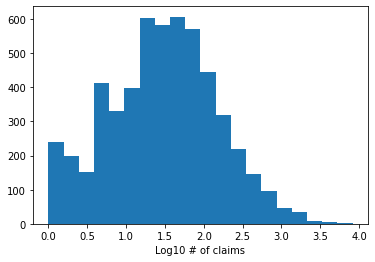

```python
plt.hist(np.log10(claim_count['count'].values), bins = 20)
plt.xlabel('Log10 # of claims')
plt.show()
```

### Number of claims from each group of providers

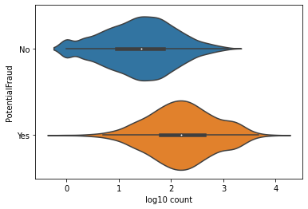

```python
claim_count['log10 count'] = np.log10(claim_count['count'])
sns.violinplot(data = claim_count, y = 'PotentialFraud', x = 'log10 count', orient = 'h', order = ['No', 'Yes'])
plt.show()
```

### Proportion of fradulent claim over time

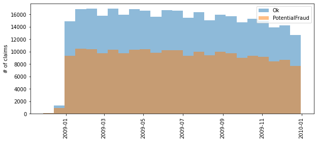

```python
plt.figure(figsize = (10, 4))
_, bins, _ = plt.hist(merged_df['ClaimStartDt'].loc[merged_df['PotentialFraud'] == 'No'], bins = 24, label = 'Ok', alpha = 0.5)
plt.hist(merged_df['ClaimStartDt'].loc[merged_df['PotentialFraud'] == 'Yes'], bins = bins, label = 'PotentialFraud', alpha = 0.5)
plt.xticks(rotation = 90)
plt.ylabel('# of claims')
plt.legend()
plt.show()
```

### Distribution of patients across states

```python
location_profile = pd.crosstab(merged_df['Provider'], merged_df['State'])
location_profile.head(5)
```

| State Provider | 1 | 2 | 3 | 4 | 5 | 6 | 7 | 8 | 9 | 10 | ... | 44 | 45 | 46 | 47 | 49 | 50 | 51 | 52 | 53 | 54 |
| --- | --- | --- | --- | --- | --- | --- | --- | --- | --- | --- | --- | --- | --- | --- | --- | --- | --- | --- | --- | --- | --- |
| PRV51001 | 25 | 0 | 0 | 0 | 0 | 0 | 0 | 0 | 0 | 0 | ... | 0 | 0 | 0 | 0 | 0 | 0 | 0 | 0 | 0 | 0 |
| PRV51003 | 95 | 0 | 0 | 0 | 0 | 0 | 0 | 0 | 0 | 23 | ... | 0 | 0 | 0 | 0 | 0 | 0 | 0 | 0 | 0 | 0 |
| PRV51004 | 75 | 0 | 0 | 0 | 0 | 0 | 0 | 0 | 0 | 6 | ... | 0 | 0 | 0 | 0 | 0 | 0 | 0 | 7 | 0 | 0 |
| PRV51005 | 1148 | 0 | 0 | 0 | 0 | 0 | 0 | 0 | 0 | 1 | ... | 0 | 0 | 0 | 0 | 0 | 0 | 0 | 0 | 0 | 0 |
| PRV51007 | 66 | 0 | 0 | 0 | 0 | 0 | 0 | 0 | 0 | 0 | ... | 0 | 0 | 0 | 0 | 0 | 0 | 0 | 0 | 0 | 0 |

5 rows × 52 columns

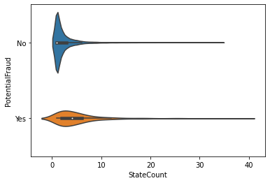

```python
location_profile['StateCount'] = (location_profile.iloc[:, :52] > 0).sum(axis = 1)
location_profile['PotentialFraud'] = all_df['Label']['PotentialFraud']

sns.violinplot(data = location_profile, y = 'PotentialFraud', x = 'StateCount', orient = 'h', order = ['No', 'Yes'])
plt.show()
```

```python
location_fraud_profile = pd.crosstab(merged_df['State'], merged_df['PotentialFraud'], normalize = 'index') * 100
location_fraud_profile = location_fraud_profile.sort_values('Yes', ascending = False)
location_fraud_profile.head()
```

| PotentialFraud State | No | Yes |
| --- | --- | --- |
| 46 | 37.178350 | 62.821650 |
| 5 | 40.925024 | 59.074976 |
| 49 | 42.568514 | 57.431486 |
| 22 | 42.762772 | 57.237228 |
| 31 | 42.835634 | 57.164366 |

### Association between chronic conditions and fraud

There is no explanation for 1 and 2 so we are guessing from **Alzheimer**, **Cancer**, and **Diabetes** that `1` is Yes

```python
display(merged_df['ChronicCond_Alzheimer'].value_counts())
display(merged_df['ChronicCond_Cancer'].value_counts())
display(merged_df['ChronicCond_Diabetes'].value_counts())
```

```
ChronicCond_Alzheimer
2    333884
1    224327
Name: count, dtype: int64
```

```
ChronicCond_Cancer
2    473706
1     84505
Name: count, dtype: int64
```

```
ChronicCond_Diabetes
1    393759
2    164452
Name: count, dtype: int64
```

```python
condition_cols = [x for x in merged_df.columns if x.startswith('ChronicCond_')]

for cond in condition_cols:
    table = pd.crosstab(merged_df[cond] == 1, merged_df['PotentialFraud'] == 'Yes')
    pvalue = fisher_exact(table).pvalue
    enrich = (table.loc[True, True] / table.loc[True].sum()) / (table.loc[False, True] / table.loc[False].sum())

    if pvalue < 0.01 and enrich > 1.1:
        print(cond, pvalue, enrich)
        display(pd.crosstab(merged_df[cond] == 1, merged_df['PotentialFraud'] == 'Yes', normalize = 'index'))
```

### Chronic condition vs provider

```python
condition_provider = all_df['Label'].copy()

for cond in condition_cols:
    condition_provider[cond] = 2 - merged_df[[cond, 'Provider']].groupby('Provider').mean()[cond]

condition_provider.head()
```

| Provider | PotentialFraud | ChronicCond_Alzheimer | ChronicCond_Heartfailure | ChronicCond_KidneyDisease | ChronicCond_Cancer | ChronicCond_ObstrPulmonary | ChronicCond_Depression | ChronicCond_Diabetes | ChronicCond_IschemicHeart | ChronicCond_Osteoporasis | ChronicCond_rheumatoidarthritis | ChronicCond_stroke |
| --- | --- | --- | --- | --- | --- | --- | --- | --- | --- | --- | --- | --- |
| PRV51001 | No | 0.600000 | 0.760000 | 0.680000 | 0.200000 | 0.400000 | 0.360000 | 0.840000 | 0.920000 | 0.240000 | 0.320000 | 0.240000 |
| PRV51003 | Yes | 0.424242 | 0.606061 | 0.484848 | 0.075758 | 0.310606 | 0.409091 | 0.757576 | 0.848485 | 0.250000 | 0.287879 | 0.090909 |
| PRV51004 | No | 0.429530 | 0.590604 | 0.335570 | 0.107383 | 0.275168 | 0.422819 | 0.704698 | 0.724832 | 0.328859 | 0.308725 | 0.114094 |
| PRV51005 | Yes | 0.365665 | 0.583691 | 0.435193 | 0.141631 | 0.253219 | 0.416309 | 0.685837 | 0.768240 | 0.295279 | 0.284120 | 0.106438 |
| PRV51007 | No | 0.361111 | 0.555556 | 0.305556 | 0.166667 | 0.222222 | 0.402778 | 0.680556 | 0.708333 | 0.291667 | 0.305556 | 0.166667 |

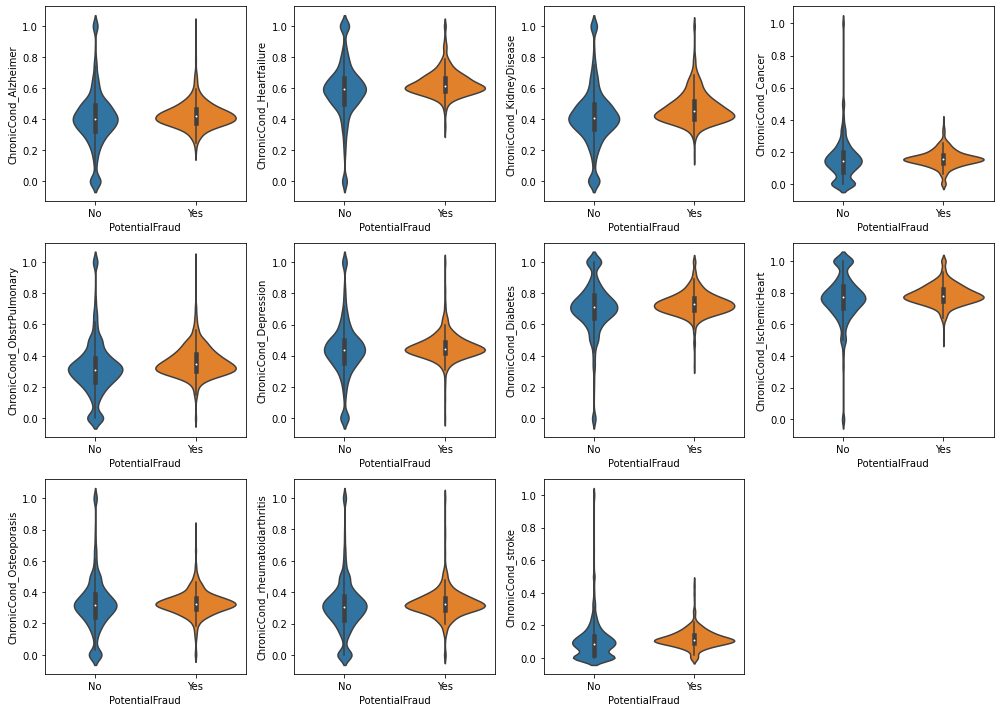

```python
plt.figure(figsize = (14, 10))

for i in range(len(condition_cols)):
    plt.subplot(3, 4, i + 1)
    sns.violinplot(data = condition_provider, x = 'PotentialFraud', y = condition_cols[i])

plt.tight_layout()
plt.show()
```

## Take 1: Predict fradulent providers using annual statistics

Use `claim_count` dataframe as the start

Add average `InscClaimAmtReimbursed` and frequency of chronic conditions

### Drop providers with <100 claims

```python
annual_stats = claim_count.iloc[:, :2].copy(); annual_stats.columns = ['PotentialFraud', 'ClaimCount']
annual_stats['AverageInscClaimAmtReimbursed'] = merged_df[['InscClaimAmtReimbursed', 'Provider']].groupby('Provider').mean()
annual_stats[condition_cols] = condition_provider[condition_cols]

annual_stats = annual_stats.loc[annual_stats['ClaimCount'] >= 100]

print(annual_stats.shape)
print('number of fradulent providers:', (annual_stats['PotentialFraud'] == 'Yes').sum())

display(annual_stats.head())
display(annual_stats.tail())
```

```
(1228, 14)
number of fradulent providers: 322
```

| Provider | PotentialFraud | ClaimCount | AverageInscClaimAmtReimbursed | ChronicCond_Alzheimer | ChronicCond_Heartfailure | ChronicCond_KidneyDisease | ChronicCond_Cancer | ChronicCond_ObstrPulmonary | ChronicCond_Depression | ChronicCond_Diabetes | ChronicCond_IschemicHeart | ChronicCond_Osteoporasis | ChronicCond_rheumatoidarthritis | ChronicCond_stroke |
| --- | --- | --- | --- | --- | --- | --- | --- | --- | --- | --- | --- | --- | --- | --- |
| PRV51459 | Yes | 8240 | 281.782767 | 0.398301 | 0.562864 | 0.377549 | 0.150243 | 0.280583 | 0.435922 | 0.701942 | 0.737136 | 0.307160 | 0.304733 | 0.098301 |
| PRV53797 | Yes | 4739 | 275.079131 | 0.397552 | 0.570162 | 0.386368 | 0.158894 | 0.282127 | 0.417810 | 0.690230 | 0.741296 | 0.298586 | 0.301540 | 0.091792 |
| PRV51574 | Yes | 4444 | 288.436094 | 0.404365 | 0.594734 | 0.428893 | 0.156616 | 0.324932 | 0.445770 | 0.703195 | 0.743024 | 0.329433 | 0.309631 | 0.087309 |
| PRV53918 | Yes | 3588 | 282.750836 | 0.377926 | 0.593924 | 0.395764 | 0.145764 | 0.289019 | 0.408584 | 0.693701 | 0.755017 | 0.307692 | 0.297380 | 0.102564 |
| PRV54895 | Yes | 3436 | 307.802678 | 0.388533 | 0.583818 | 0.418219 | 0.156868 | 0.328580 | 0.440338 | 0.678405 | 0.763097 | 0.351572 | 0.291036 | 0.086438 |

| Provider | PotentialFraud | ClaimCount | AverageInscClaimAmtReimbursed | ChronicCond_Alzheimer | ChronicCond_Heartfailure | ChronicCond_KidneyDisease | ChronicCond_Cancer | ChronicCond_ObstrPulmonary | ChronicCond_Depression | ChronicCond_Diabetes | ChronicCond_IschemicHeart | ChronicCond_Osteoporasis | ChronicCond_rheumatoidarthritis | ChronicCond_stroke |
| --- | --- | --- | --- | --- | --- | --- | --- | --- | --- | --- | --- | --- | --- | --- |
| PRV57197 | No | 100 | 1155.4 | 0.46 | 0.51 | 0.51 | 0.16 | 0.37 | 0.53 | 0.63 | 0.77 | 0.40 | 0.41 | 0.16 |
| PRV55002 | No | 100 | 270.6 | 0.54 | 0.59 | 0.41 | 0.15 | 0.33 | 0.45 | 0.73 | 0.75 | 0.29 | 0.36 | 0.11 |
| PRV52519 | No | 100 | 1371.8 | 0.27 | 0.63 | 0.40 | 0.32 | 0.36 | 0.33 | 0.78 | 0.77 | 0.34 | 0.26 | 0.11 |
| PRV54354 | Yes | 100 | 2596.2 | 0.41 | 0.69 | 0.50 | 0.14 | 0.34 | 0.40 | 0.73 | 0.82 | 0.32 | 0.24 | 0.14 |
| PRV52166 | No | 100 | 693.0 | 0.37 | 0.56 | 0.49 | 0.18 | 0.42 | 0.42 | 0.68 | 0.84 | 0.26 | 0.38 | 0.07 |

### Separate input and label

```python
X = annual_stats.iloc[:, 1:]
y = (annual_stats.iloc[:, 0] == 'Yes').astype(int)
```

### Log-transform features with large ranges

`ClaimCount` and `AverageInscClaimAmtReimbursed`

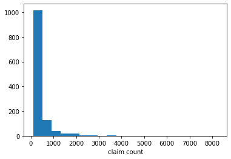

```python
plt.hist(X['ClaimCount'], bins = 20); plt.xlabel('claim count'); plt.show()
# plt.hist(X['AverageInscClaimAmtReimbursed'], bins = 20); plt.xlabel('average reimbursement'); plt.show()
```

```python
X.loc[:, ['ClaimCount', 'AverageInscClaimAmtReimbursed']] = np.log10(X.loc[:, ['ClaimCount', 'AverageInscClaimAmtReimbursed']])
```

### Standardize

```python
X_std = (X - X.mean()) / X.std()
```

### Split the data

Set `stratify = y` to ensure that the splits contain the same fraction of positive/negative

Set `test_size` to control the split size

```python
X_train, X_test, y_train, y_test = train_test_split(X_std, y, stratify = y, test_size = 0.25,
                                                    shuffle = True, random_state = 4649)
```

Set up `StratifiedKFold` here so that every cross-validation performed will use the same data splits

```python
cv_split = StratifiedKFold(n_splits = 5, shuffle = True, random_state = 4649)
```

## Tune the hyperparameters using `GridSearchCV`

Grid search is a simple method for tuning where you define a grid of all possible values to explore

### Let's start with `LogisticRegression`

Set `solver = 'liblinear'` because LASSO regularization requires it

`C` is the inverse regularization coefficient ($\text{objective} = C \cdot \text{loss} + \text{regularization}$)

While tuning the model, we can measure multiple performance metrics by specifying `scoring` in `GridSearchCV`. See [this page](https://scikit-learn.org/stable/modules/model_evaluation.html) for the names of defined metrics

Then, we set `refit` to specify which metric would be our main one for tuning the hyperparameters

```python
base_logistic = LogisticRegression(solver = 'liblinear', max_iter = 1000, random_state = 4649)
param_logistic = {'C': np.logspace(-5, 5, 11), 'penalty': ['l1', 'l2']}

grid_logistic = GridSearchCV(estimator = base_logistic, param_grid = param_logistic, cv = cv_split,
                             scoring = ['accuracy', 'roc_auc', 'average_precision', 'f1'],
                             refit = 'roc_auc', n_jobs = 3)
```

```python
grid_logistic.fit(X_train, y_train)
```

```
GridSearchCV(cv=StratifiedKFold(n_splits=5, random_state=4649, shuffle=True),
             estimator=LogisticRegression(max_iter=1000, random_state=4649,
                                          solver='liblinear'),
             n_jobs=3,
             param_grid={'C': array([1.e-05, 1.e-04, 1.e-03, 1.e-02, 1.e-01, 1.e+00, 1.e+01, 1.e+02,
       1.e+03, 1.e+04, 1.e+05]),
                         'penalty': ['l1', 'l2']},
             refit='roc_auc',
             scoring=['accuracy', 'roc_auc', 'average_precision', 'f1'])
```

## We want the `cv_results_` output from `GridSearchCV`

It is a dictionary, which can be converted into a dataframe

Columns with names beginning with `rank_test_` are the rank of hyperparameters based on each metric

Performance scores are reported for all splits (`split0`, ..., `split4`)

```python
grid_logistic_scores = pd.DataFrame(grid_logistic.cv_results_).sort_values(by = 'rank_test_roc_auc')
grid_logistic_scores.head()
```

|  | mean_fit_time | std_fit_time | mean_score_time | std_score_time | param_C | param_penalty | params | split0_test_accuracy | split1_test_accuracy | split2_test_accuracy | ... | std_test_average_precision | rank_test_average_precision | split0_test_f1 | split1_test_f1 | split2_test_f1 | split3_test_f1 | split4_test_f1 | mean_test_f1 | std_test_f1 | rank_test_f1 |
| --- | --- | --- | --- | --- | --- | --- | --- | --- | --- | --- | --- | --- | --- | --- | --- | --- | --- | --- | --- | --- | --- |
| 8 | 0.003385 | 0.000490 | 0.007181 | 0.000744 | 0.1 | l1 | {'C': 0.1, 'penalty': 'l1'} | 0.837838 | 0.836957 | 0.869565 | ... | 0.029431 | 1 | 0.666667 | 0.659091 | 0.720930 | 0.729412 | 0.632653 | 0.681751 | 0.037305 | 4 |
| 10 | 0.004788 | 0.001467 | 0.009175 | 0.002215 | 1.0 | l1 | {'C': 1.0, 'penalty': 'l1'} | 0.827027 | 0.836957 | 0.858696 | ... | 0.030828 | 2 | 0.666667 | 0.666667 | 0.690476 | 0.735632 | 0.653061 | 0.682501 | 0.029171 | 2 |
| 9 | 0.003586 | 0.000485 | 0.006788 | 0.000402 | 0.1 | l2 | {'C': 0.1, 'penalty': 'l2'} | 0.821622 | 0.836957 | 0.858696 | ... | 0.029732 | 14 | 0.645161 | 0.666667 | 0.690476 | 0.752941 | 0.659794 | 0.683008 | 0.037907 | 1 |
| 11 | 0.004386 | 0.001018 | 0.009775 | 0.001934 | 1.0 | l2 | {'C': 1.0, 'penalty': 'l2'} | 0.827027 | 0.831522 | 0.858696 | ... | 0.031878 | 13 | 0.659574 | 0.659341 | 0.690476 | 0.735632 | 0.666667 | 0.682338 | 0.028980 | 3 |
| 19 | 0.003998 | 0.001097 | 0.008572 | 0.002050 | 10000.0 | l2 | {'C': 10000.0, 'penalty': 'l2'} | 0.827027 | 0.826087 | 0.858696 | ... | 0.032743 | 3 | 0.659574 | 0.644444 | 0.690476 | 0.735632 | 0.666667 | 0.679359 | 0.031818 | 5 |

5 rows × 39 columns

### Simplify the view

**Note**: Performances do not differ much among similar hyperparameters. You DO NOT need to tune aggressively!

The best hyperparameter is `penalty = 'l1'` (LASSO) with `C = 0.1` which achieve **AUROC of 0.8845**

```python
focus_columns = ['params', 'mean_test_accuracy', 'mean_test_roc_auc', 'mean_test_average_precision', 'mean_test_f1']
grid_logistic_scores[focus_columns].head()
```

|  | params | mean_test_accuracy | mean_test_roc_auc | mean_test_average_precision | mean_test_f1 |
| --- | --- | --- | --- | --- | --- |
| 8 | {'C': 0.1, 'penalty': 'l1'} | 0.844741 | 0.884506 | 0.776002 | 0.681751 |
| 10 | {'C': 1.0, 'penalty': 'l1'} | 0.842579 | 0.880032 | 0.775940 | 0.682501 |
| 9 | {'C': 0.1, 'penalty': 'l2'} | 0.844759 | 0.879941 | 0.770938 | 0.683008 |
| 11 | {'C': 1.0, 'penalty': 'l2'} | 0.842579 | 0.879125 | 0.773522 | 0.682338 |
| 19 | {'C': 10000.0, 'penalty': 'l2'} | 0.841492 | 0.879067 | 0.774528 | 0.679359 |

### Next, a random forest model

Set `n_estimators` to be large enough is usually all you need to do because the bagging technique helps against overfitting

To illustrate, we also tune `max_depth` and `min_samples_split`

```python
base_rf = RandomForestClassifier(n_estimators = 300, random_state = 4649)
param_rf = {'max_depth': [10, 20, None], 'min_samples_split': [2, 5, 10]}

grid_rf = GridSearchCV(estimator = base_rf, param_grid = param_rf, cv = cv_split,
                       scoring = ['accuracy', 'roc_auc', 'average_precision', 'f1'],
                       refit = 'roc_auc', n_jobs = 3)
```

Fitting will take some times because 300 trees are built for every hyperparameter set

```python
grid_rf.fit(X_train, y_train)
```

```
GridSearchCV(cv=StratifiedKFold(n_splits=5, random_state=4649, shuffle=True),
             estimator=RandomForestClassifier(n_estimators=300,
                                              random_state=4649),
             n_jobs=3,
             param_grid={'max_depth': [10, 20, None],
                         'min_samples_split': [2, 5, 10]},
             refit='roc_auc',
             scoring=['accuracy', 'roc_auc', 'average_precision', 'f1'])
```

**Note**: If you see that the best hyperparameters occur at the edge of your range, you might want to try more values

Here, it seems that the higher `min_samples_split` yields better performance. So, we might want to try increasing it further

```python
grid_rf_scores = pd.DataFrame(grid_rf.cv_results_).sort_values(by = 'rank_test_roc_auc')
grid_rf_scores[focus_columns].head()
```

|  | params | mean_test_accuracy | mean_test_roc_auc | mean_test_average_precision | mean_test_f1 |
| --- | --- | --- | --- | --- | --- |
| 5 | {'max_depth': 20, 'min_samples_split': 10} | 0.837150 | 0.873571 | 0.768921 | 0.626956 |
| 8 | {'max_depth': None, 'min_samples_split': 10} | 0.837150 | 0.873571 | 0.768921 | 0.626956 |
| 2 | {'max_depth': 10, 'min_samples_split': 10} | 0.836052 | 0.872447 | 0.767175 | 0.625640 |
| 4 | {'max_depth': 20, 'min_samples_split': 5} | 0.834971 | 0.869764 | 0.763688 | 0.620003 |
| 7 | {'max_depth': None, 'min_samples_split': 5} | 0.834971 | 0.869549 | 0.763242 | 0.620003 |

## Let's say that we aim to explore only these two models

## Now, we can compare them side by side on the training and test sets

`GridSearchCV` ran with `refit` option will readily provide the fitted model with the best hyperparametr through `.best_estimator_`

```python
tuned_logistic = grid_logistic.best_estimator_
tuned_rf = grid_rf.best_estimator_
```

Use `predict_proba()` to obtain predicted probabilities (confidences) or `predict()` to obtain the classes

Extract only predicted probabilities for the positive class using `[:, 1]`

```python
pred_train_logistic = tuned_logistic.predict_proba(X_train)[:, 1]
pred_test_logistic = tuned_logistic.predict_proba(X_test)[:, 1]

pred_train_rf = tuned_rf.predict_proba(X_train)[:, 1]
pred_test_rf = tuned_rf.predict_proba(X_test)[:, 1]
```

### Performance on the training set (data that the models saw)

`classification_report()` provides an overview

```python
print(classification_report(y_train, pred_train_logistic > 0.5))
```

```
              precision    recall  f1-score   support

           0       0.88      0.93      0.90       679
           1       0.75      0.63      0.69       242

    accuracy                           0.85       921
   macro avg       0.81      0.78      0.79       921
weighted avg       0.84      0.85      0.84       921
```

Random forest fits the seen data almost perfectly

```python
print(classification_report(y_train, pred_train_rf > 0.5))
```

```
              precision    recall  f1-score   support

           0       0.95      1.00      0.98       679
           1       0.99      0.87      0.93       242

    accuracy                           0.96       921
   macro avg       0.97      0.93      0.95       921
weighted avg       0.96      0.96      0.96       921
```

### Performance on the test set

Notice how linear model performs similarly on both sets while random forest differs greatly

```python
print(classification_report(y_test, pred_test_logistic > 0.5))
```

```
              precision    recall  f1-score   support

           0       0.88      0.95      0.91       227
           1       0.81      0.62      0.70        80

    accuracy                           0.86       307
   macro avg       0.84      0.79      0.81       307
weighted avg       0.86      0.86      0.86       307
```

```python
print(classification_report(y_test, pred_test_rf > 0.5))
```

```
              precision    recall  f1-score   support

           0       0.86      0.95      0.90       227
           1       0.79      0.56      0.66        80

    accuracy                           0.85       307
   macro avg       0.82      0.75      0.78       307
weighted avg       0.84      0.85      0.84       307
```

### Confusion matrix shows the balance between false positive and false negative

|  | Predicted Negative | Predicted Positive |
| --- | --- | --- |
| Negative | TN | FP |
| Positive | FN | TP |

Both models made the same number of false positives (FP) but random forest made more false negatives (FN)

```python
print(confusion_matrix(y_test, pred_test_logistic > 0.5))
```

```
[[215  12]
 [ 30  50]]
```

```python
print(confusion_matrix(y_test, pred_test_rf > 0.5))
```

```
[[215  12]
 [ 35  45]]
```

## Visualize logistic regression coefficients

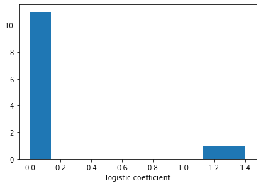

```python
coefficients = grid_logistic.best_estimator_.coef_[0]

plt.hist(coefficients, bins = 10)
plt.xlabel('logistic coefficient')
plt.show()
```

What are the most important features?

```python
print('Fradulent-indicating features:', list(X.columns[coefficients > 1]))
```

```
Fradulent-indicating features: ['ClaimCount', 'AverageInscClaimAmtReimbursed']
```

## Visualize random forest feature importance

`feature_importances_`

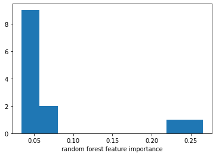

```python
feature_importance = grid_rf.best_estimator_.feature_importances_

plt.hist(feature_importance, bins = 10)
plt.xlabel('random forest feature importance')
plt.show()
```

```python
print('Important features:', list(X.columns[feature_importance > 0.05]))
```

```
Important features: ['ClaimCount', 'AverageInscClaimAmtReimbursed', 'ChronicCond_KidneyDisease', 'ChronicCond_ObstrPulmonary', 'ChronicCond_stroke']
```

## Visualize data on the top two features

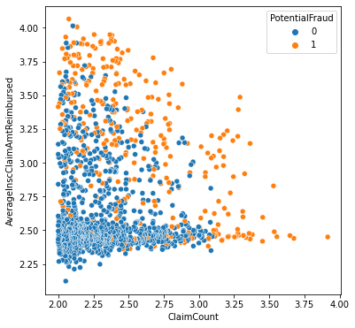

```python
local = X.copy(); local['PotentialFraud'] = y

plt.figure(figsize = (6, 6))
sns.scatterplot(data = local, x = 'ClaimCount', y = 'AverageInscClaimAmtReimbursed', hue = 'PotentialFraud')
plt.show()
```

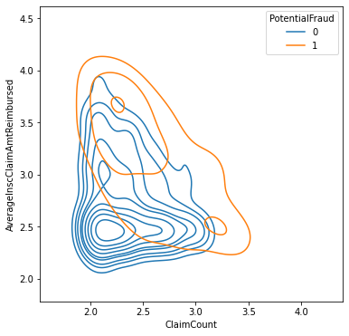

```python
plt.figure(figsize = (6, 6))
sns.kdeplot(data = local, x = 'ClaimCount', y = 'AverageInscClaimAmtReimbursed', hue = 'PotentialFraud')
plt.show()
```

## Take 2: Predict fradulent providers by predicting individual fradulent claims

**Key Issues**: Not every claim from a fraudulent provider is fraudulent. Legitimate provider can also make mistakes.

But let's try anyway

## First, feature cleaning

Identify features with too many missing values

```python
missing_count = pd.isna(merged_df).sum()
display(missing_count[missing_count > 0])
```

```
AttendingPhysician         1508
OperatingPhysician       443764
OtherPhysician           358475
ClmAdmitDiagnosisCode    412312
DeductibleAmtPaid           899
ClmDiagnosisCode_1        10453
ClmDiagnosisCode_2       195606
ClmDiagnosisCode_3       315156
ClmDiagnosisCode_4       393675
ClmDiagnosisCode_5       446287
ClmDiagnosisCode_6       473819
ClmDiagnosisCode_7       492034
ClmDiagnosisCode_8       504767
ClmDiagnosisCode_9       516396
ClmDiagnosisCode_10      553201
ClmProcedureCode_1       534901
ClmProcedureCode_2       552721
ClmProcedureCode_3       557242
ClmProcedureCode_4       558093
ClmProcedureCode_5       558202
ClmProcedureCode_6       558211
DOD                      554080
dtype: int64
```

### Drop features with >12,000 missing values

```python
cleaned_df = merged_df.drop(missing_count.index[missing_count > 12000], axis = 1)
print(cleaned_df.shape)
```

```
(558211, 32)
```

### Drop `Provider` (cannot be used on new provider), `County` (too detailed), and IDs (no information)

`DataFrame.drop()`

```python
cleaned_df = cleaned_df.drop(['Provider', 'County', 'BeneID', 'AttendingPhysician'], axis = 1)
```

### Transform `DOB` into `Age` at the time of claim

`date` object can be subtracted directly

```python
cleaned_df['Age'] = (cleaned_df['ClaimStartDt'] - cleaned_df['DOB']) / timedelta(days = 365)
cleaned_df = cleaned_df.drop(['DOB'], axis = 1)
```

### Transform `ClaimStartDt` and `ClaimEndDt` into `ClaimDuration`

```python
cleaned_df['ClaimDuration'] = (cleaned_df['ClaimEndDt'] - cleaned_df['ClaimStartDt']) / timedelta(days = 30)
cleaned_df = cleaned_df.drop(['ClaimEndDt', 'ClaimStartDt'], axis = 1)
```

### Impute missing value (`DeductibleAmtPaid` with `0` and `ClmDiagnosisCode_1` with `-1`)

`DataFrame.fillna()`

```python
cleaned_df.loc[:, 'DeductibleAmtPaid'] = cleaned_df['DeductibleAmtPaid'].fillna(0)
cleaned_df.loc[:, 'ClmDiagnosisCode_1'] = cleaned_df['ClmDiagnosisCode_1'].fillna(-1)
```

## Log-transform money amounts

Becareful that some amounts are negative

Columns with `Amt` as part of the names. Add `+ 1` to avoid zeros

```python
amt_columns = [x for x in cleaned_df.columns if 'Amt' in x]
cleaned_df[['Log10' + x for x in amt_columns]] = np.log10(np.abs(cleaned_df[amt_columns]) + 1) * np.sign(cleaned_df[amt_columns])
cleaned_df = cleaned_df.drop(amt_columns, axis = 1)
```

## Clean condition indicator columns so that `1` means `Yes`

```python
cleaned_df.loc[:, 'RenalDiseaseIndicator'] = (cleaned_df['RenalDiseaseIndicator'] == 'Y').astype(int)
cleaned_df.loc[:, condition_cols] = 2 - cleaned_df.loc[:, condition_cols]
```

## Convert categorical columns (more than 2 classes) to one-hot encoding

`Race`, `State`, and `ClmDiagnosisCode_1`

### First, drop rare `ClmDiagnosisCode` to prevent too many categories

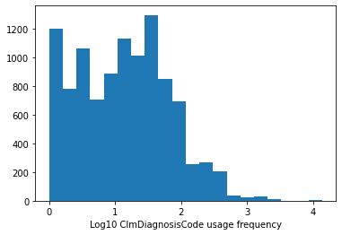

```python
plt.hist(np.log10(cleaned_df['ClmDiagnosisCode_1'].value_counts().values), bins = 20)
plt.xlabel('Log10 ClmDiagnosisCode usage frequency')
plt.show()
```

### Cutoff at 500 claims

```python
retained_codes = cleaned_df['ClmDiagnosisCode_1'].value_counts()
print('all codes:', retained_codes.shape[0])

retained_codes = retained_codes.index[retained_codes >= 500]
print('retained codes:', len(retained_codes))

processed_df = cleaned_df.loc[cleaned_df['ClmDiagnosisCode_1'].isin(retained_codes)].copy()
print('passed entries:', processed_df.shape[0], 'from', cleaned_df.shape[0])
```

```
all codes: 10451
retained codes: 104
passed entries: 156473 from 558211
```

Use `pandas.get_dummies()` which will automatically create new column names based on the categorical values

```python
cat_columns = ['ClmDiagnosisCode_1', 'Gender', 'Race', 'State']
processed_df = pd.get_dummies(processed_df, columns = cat_columns)
```

### Check the distribution for `State`

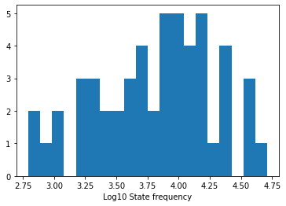

```python
plt.hist(np.log10(cleaned_df['State'].value_counts().values), bins = 20)
plt.xlabel('Log10 State frequency')
plt.show()
```

```python
processed_df
```

| ClaimID | RenalDiseaseIndicator | NoOfMonths_PartACov | NoOfMonths_PartBCov | ChronicCond_Alzheimer | ChronicCond_Heartfailure | ChronicCond_KidneyDisease | ChronicCond_Cancer | ChronicCond_ObstrPulmonary | ChronicCond_Depression | ChronicCond_Diabetes | ... | State_44 | State_45 | State_46 | State_47 | State_49 | State_50 | State_51 | State_52 | State_53 | State_54 |
| --- | --- | --- | --- | --- | --- | --- | --- | --- | --- | --- | --- | --- | --- | --- | --- | --- | --- | --- | --- | --- | --- |
| CLM38412 | 0 | 12 | 12 | 0 | 1 | 1 | 0 | 0 | 1 | 1 | ... | False | False | False | False | False | False | False | False | False | False |
| CLM62784 | 0 | 12 | 12 | 0 | 1 | 1 | 0 | 0 | 0 | 0 | ... | False | False | False | False | False | False | False | False | False | False |
| CLM54944 | 0 | 12 | 12 | 0 | 1 | 1 | 0 | 1 | 1 | 1 | ... | False | False | False | False | False | False | False | False | False | False |
| CLM54477 | 1 | 12 | 12 | 0 | 1 | 1 | 0 | 1 | 1 | 1 | ... | False | False | False | False | True | False | False | False | False | False |
| CLM41414 | 0 | 12 | 12 | 0 | 1 | 1 | 0 | 1 | 1 | 1 | ... | False | False | False | False | False | False | False | False | False | False |
| ... | ... | ... | ... | ... | ... | ... | ... | ... | ... | ... | ... | ... | ... | ... | ... | ... | ... | ... | ... | ... | ... |
| CLM540893 | 0 | 12 | 12 | 0 | 1 | 1 | 1 | 0 | 1 | 1 | ... | False | False | False | False | False | False | False | False | False | False |
| CLM698270 | 0 | 12 | 12 | 1 | 1 | 0 | 0 | 0 | 0 | 0 | ... | False | False | False | False | False | False | False | False | False | False |
| CLM172248 | 0 | 12 | 12 | 1 | 1 | 0 | 0 | 0 | 1 | 1 | ... | False | False | False | False | False | False | False | False | False | False |
| CLM636992 | 0 | 12 | 12 | 1 | 1 | 0 | 0 | 0 | 1 | 1 | ... | False | False | False | False | False | False | False | False | False | False |
| CLM686139 | 0 | 12 | 12 | 1 | 1 | 0 | 0 | 0 | 1 | 1 | ... | False | False | False | False | False | False | False | False | False | False |

156473 rows × 185 columns

## Let's proceed with data spliting and model development

```python
X = processed_df.drop(['PotentialFraud'], axis = 1)
y = (processed_df['PotentialFraud'] == 'Yes').astype(int)
```

For large table, using `StandardScaler()` is much faster

```python
std_scaler = StandardScaler().fit(X)
X_std = std_scaler.transform(X)
```

```python
X_train, X_test, y_train, y_test = train_test_split(X_std, y, stratify = y, test_size = 0.25,
                                                    shuffle = True, random_state = 4649)

cv_split = StratifiedKFold(n_splits = 5, shuffle = True, random_state = 4649)
```

### To speed things up, we will not tune the hyperparameters much

```python
base_logistic_claim = LogisticRegression(max_iter = 1000, random_state = 4649)
param_logistic_claim = {'C': np.logspace(-5, 5, 11), 'penalty': ['l2']}

grid_logistic_claim = GridSearchCV(estimator = base_logistic_claim, param_grid = param_logistic_claim, cv = cv_split,
                                   scoring = ['accuracy', 'roc_auc', 'average_precision', 'f1'],
                                   refit = 'roc_auc', n_jobs = 1)

grid_logistic_claim.fit(X_train, y_train)
```

```
GridSearchCV(cv=StratifiedKFold(n_splits=5, random_state=4649, shuffle=True),
             estimator=LogisticRegression(max_iter=1000, random_state=4649),
             n_jobs=1,
             param_grid={'C': array([1.e-05, 1.e-04, 1.e-03, 1.e-02, 1.e-01, 1.e+00, 1.e+01, 1.e+02,
       1.e+03, 1.e+04, 1.e+05]),
                         'penalty': ['l2']},
             refit='roc_auc',
             scoring=['accuracy', 'roc_auc', 'average_precision', 'f1'])
```

```python
base_rf_claim = RandomForestClassifier(n_estimators = 300, random_state = 4649, n_jobs = 6)
param_rf_claim = {'max_depth': [30], 'min_samples_split': [25], 'max_features': [0.2]}

grid_rf_claim = GridSearchCV(estimator = base_rf_claim, param_grid = param_rf_claim, cv = cv_split,
                             scoring = ['accuracy', 'roc_auc', 'average_precision', 'f1'],
                             refit = 'roc_auc', n_jobs = 1, verbose = 3)

grid_rf_claim.fit(X_train, y_train)
```

```
Fitting 5 folds for each of 1 candidates, totalling 5 fits
[CV 1/5] END max_depth=30, max_features=0.2, min_samples_split=25; accuracy: (test=0.669) average_precision: (test=0.582) f1: (test=0.500) roc_auc: (test=0.705) total time= 1.3min
[CV 2/5] END max_depth=30, max_features=0.2, min_samples_split=25; accuracy: (test=0.667) average_precision: (test=0.581) f1: (test=0.498) roc_auc: (test=0.701) total time= 1.3min
[CV 3/5] END max_depth=30, max_features=0.2, min_samples_split=25; accuracy: (test=0.668) average_precision: (test=0.574) f1: (test=0.505) roc_auc: (test=0.699) total time= 1.3min
[CV 4/5] END max_depth=30, max_features=0.2, min_samples_split=25; accuracy: (test=0.670) average_precision: (test=0.577) f1: (test=0.501) roc_auc: (test=0.705) total time= 1.2min
[CV 5/5] END max_depth=30, max_features=0.2, min_samples_split=25; accuracy: (test=0.667) average_precision: (test=0.578) f1: (test=0.498) roc_auc: (test=0.700) total time= 1.2min
```

```
GridSearchCV(cv=StratifiedKFold(n_splits=5, random_state=4649, shuffle=True),
             estimator=RandomForestClassifier(n_estimators=300, n_jobs=6,
                                              random_state=4649),
             n_jobs=1,
             param_grid={'max_depth': [30], 'max_features': [0.2],
                         'min_samples_split': [25]},
             refit='roc_auc',
             scoring=['accuracy', 'roc_auc', 'average_precision', 'f1'],
             verbose=3)
```

## Compare cross-validation results

```python
grid_logistic_claim_scores = pd.DataFrame(grid_logistic_claim.cv_results_).sort_values(by = 'rank_test_roc_auc')
grid_logistic_claim_scores[focus_columns].head()
```

|  | params | mean_test_accuracy | mean_test_roc_auc | mean_test_average_precision | mean_test_f1 |
| --- | --- | --- | --- | --- | --- |
| 1 | {'C': 0.0001, 'penalty': 'l2'} | 0.644554 | 0.682411 | 0.540417 | 0.359886 |
| 2 | {'C': 0.001, 'penalty': 'l2'} | 0.650877 | 0.681799 | 0.539897 | 0.448168 |
| 3 | {'C': 0.01, 'penalty': 'l2'} | 0.650766 | 0.681615 | 0.539731 | 0.452703 |
| 4 | {'C': 0.1, 'penalty': 'l2'} | 0.650911 | 0.681588 | 0.539701 | 0.453360 |
| 5 | {'C': 1.0, 'penalty': 'l2'} | 0.650954 | 0.681585 | 0.539699 | 0.453478 |

```python
grid_rf_claim_scores = pd.DataFrame(grid_rf_claim.cv_results_).sort_values(by = 'rank_test_roc_auc')
grid_rf_claim_scores[focus_columns].head()
```

|  | params | mean_test_accuracy | mean_test_roc_auc | mean_test_average_precision | mean_test_f1 |
| --- | --- | --- | --- | --- | --- |
| 0 | {'max_depth': 30, 'max_features': 0.2, 'min_sa... | 0.668243 | 0.701972 | 0.578616 | 0.500318 |

## Visualize logistic regression coefficients

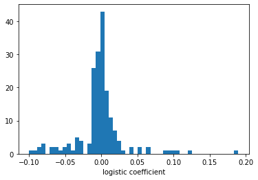

```python
coefficients = grid_logistic_claim.best_estimator_.coef_[0]

plt.hist(coefficients, bins = 50)
plt.xlabel('logistic coefficient')
plt.show()
```

What are the most important features?

```python
print('Fradulent-indicating features:', list(X.columns[coefficients > 0.05]))
print('Non-Fradulent-indicating features:', list(X.columns[coefficients < -0.05]))
```

```
Fradulent-indicating features: ['Log10DeductibleAmtPaid', 'State_5', 'State_6', 'State_10', 'State_22', 'State_31', 'State_33', 'State_39', 'State_46', 'State_49']
Non-Fradulent-indicating features: ['State_3', 'State_11', 'State_17', 'State_18', 'State_19', 'State_21', 'State_25', 'State_28', 'State_34', 'State_38', 'State_45', 'State_51', 'State_52']
```

## Visualize random forest feature importance

`feature_importances_`

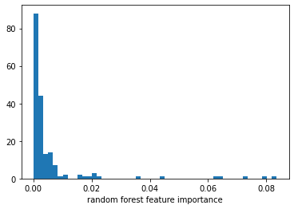

```python
feature_importance = grid_rf_claim.best_estimator_.feature_importances_

plt.hist(feature_importance, bins = 50)
plt.xlabel('random forest feature importance')
plt.show()
```

```python
print('number of features with >0.01 importance:', (feature_importance > 0.01).sum())
```

```
number of features with >0.01 importance: 17
```

```python
print('Important features:', list(X.columns[feature_importance > 0.01]))
```

[output not shown]

## Perform feature selection to assist logistic regression

`RFECV` perform cross-validation, identify features with the lowest importance, remove them, and continue the loop

Set `step` to skip multiple features at the same time

```python
rfecv = RFECV(estimator = LogisticRegression(penalty = 'l2', C = 0.001, max_iter = 1000, random_state = 4649),
              step = 5, cv = cv_split, scoring = 'roc_auc', n_jobs = 5)
rfecv.fit(X_train, y_train)
```

```
RFECV(cv=StratifiedKFold(n_splits=5, random_state=4649, shuffle=True),
      estimator=LogisticRegression(C=0.001, max_iter=1000, random_state=4649),
      n_jobs=5, scoring='roc_auc', step=5)
```

```python
rfecv.cv_results_['mean_test_score']
```

```
array([0.5404547 , 0.60055021, 0.64318295, 0.65463111, 0.66539039,
       0.67079055, 0.67516135, 0.67799306, 0.67984879, 0.68116489,
       0.68154884, 0.68169177, 0.68169569, 0.68155242, 0.68153333,
       0.68148196, 0.68149526, 0.6815388 , 0.68155227, 0.68144868,
       0.68156806, 0.68160163, 0.68158324, 0.68169851, 0.68168868,
       0.6817384 , 0.68179976, 0.68179143, 0.68182427, 0.68181737,
       0.68183271, 0.68181922, 0.68183824, 0.68182306, 0.6818031 ,
       0.68178877, 0.68179354, 0.68179906])
```

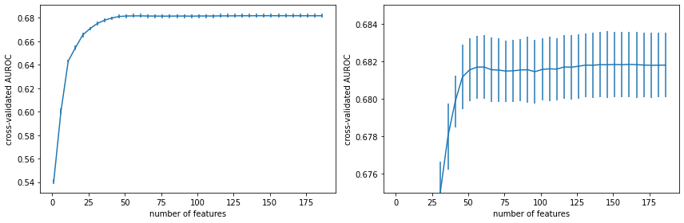

```python
plt.figure(figsize = (12, 4))

plt.subplot(1, 2, 1)
plt.errorbar(range(1, X_train.shape[1] + 5, 5),
             rfecv.cv_results_['mean_test_score'],
             yerr = rfecv.cv_results_['std_test_score'],)

plt.xlabel('number of features')
plt.ylabel('cross-validated AUROC')

plt.subplot(1, 2, 2)
plt.errorbar(range(1, X_train.shape[1] + 5, 5),
             rfecv.cv_results_['mean_test_score'],
             yerr = rfecv.cv_results_['std_test_score'],)

plt.xlabel('number of features')
plt.ylabel('cross-validated AUROC')
plt.ylim([0.675, 0.685])

plt.tight_layout()
plt.show()
```

### Conclusion: Feature selection simplifies the logistic regression model down to 50 features

## Try XGBoost

```python
import xgboost
```

XGBoost has a lot of parameters that can be tuned

```python
base_xgb = xgboost.XGBClassifier(n_estimators = 500, objective = 'binary:logistic', early_stopping_rounds = 5,
                                 learning_rate = 0.1, subsample = 0.8, colsample_bynode = 0.2, seed = 4649)

param_xgb = {'learning_rate': [0.1],
             'min_split_loss': [0.2],
             'max_depth': [30, 50, None],
             'min_child_weight': [0.5],
             'reg_lambda': [1]}

grid_xgb = GridSearchCV(estimator = base_xgb, param_grid = param_xgb, cv = cv_split,
                        scoring = ['accuracy', 'roc_auc', 'average_precision', 'f1'],
                        refit = 'roc_auc', n_jobs = 1)

grid_xgb.fit(X_train, y_train, eval_set = [(X_test, y_test)], verbose = False) ## This is cheating
```

```
GridSearchCV(cv=StratifiedKFold(n_splits=5, random_state=4649, shuffle=True),
             estimator=XGBClassifier(base_score=None, booster=None,
                                     callbacks=None, colsample_bylevel=None,
                                     colsample_bynode=0.2,
                                     colsample_bytree=None, device=None,
                                     early_stopping_rounds=5,
                                     enable_categorical=False, eval_metric=None,
                                     feature_types=None, gamma=None,
                                     grow_policy=None, importance_type=...
                                     max_leaves=None, min_child_weight=None,
                                     missing=nan, monotone_constraints=None,
                                     multi_strategy=None, n_estimators=500,
                                     n_jobs=None, num_parallel_tree=None,
                                     random_state=None, ...),
             n_jobs=1,
             param_grid={'learning_rate': [0.1], 'max_depth': [30, 50, None],
                         'min_child_weight': [0.5], 'min_split_loss': [0.2],
                         'reg_lambda': [1]},
             refit='roc_auc',
             scoring=['accuracy', 'roc_auc', 'average_precision', 'f1'])
```

```python
grid_xgb_scores = pd.DataFrame(grid_xgb.cv_results_).sort_values(by = 'rank_test_roc_auc')
grid_xgb_scores[focus_columns].head()
```

|  | params | mean_test_accuracy | mean_test_roc_auc | mean_test_average_precision | mean_test_f1 |
| --- | --- | --- | --- | --- | --- |
| 1 | {'learning_rate': 0.1, 'max_depth': 50, 'min_c... | 0.667417 | 0.702594 | 0.577974 | 0.498299 |
| 0 | {'learning_rate': 0.1, 'max_depth': 30, 'min_c... | 0.666607 | 0.702193 | 0.576048 | 0.485928 |
| 2 | {'learning_rate': 0.1, 'max_depth': None, 'min... | 0.658878 | 0.693524 | 0.561571 | 0.468962 |

## Visualize XGBoost feature importance

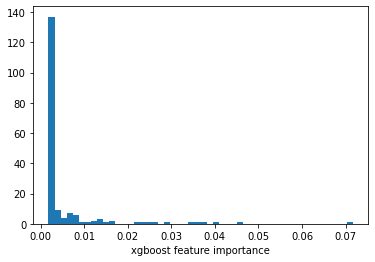

```python
xgb_feature_importance = grid_xgb.best_estimator_.feature_importances_

plt.hist(xgb_feature_importance, bins = 50)
plt.xlabel('xgboost feature importance')
plt.show()
```

```python
print('number of features with >0.01 importance:', (xgb_feature_importance > 0.01).sum())
```

```
number of features with >0.01 importance: 20
```

```python
print('Important features:', list(X.columns[xgb_feature_importance > 0.01]))
```

```
Important features: ['State_3', 'State_5', 'State_6', 'State_10', 'State_18', 'State_21', 'State_22', 'State_25', 'State_28', 'State_31', 'State_32', 'State_33', 'State_34', 'State_38', 'State_39', 'State_44', 'State_46', 'State_49', 'State_51', 'State_52']
```

### Conclusion: All models achieve similar performances but random forest provides the best explanation

## Predict fradulent claims on the test set

```python
pred_test_rf = grid_rf_claim.best_estimator_.predict_proba(X_test)[:, 1]
pred_test_logistic = grid_logistic_claim.best_estimator_.predict_proba(X_test)[:, 1]
pred_test_xgb = grid_xgb.best_estimator_.predict_proba(X_test)[:, 1]
```

There are a lot of **False Negative**

```python
print(classification_report(y_test, pred_test_rf > 0.5))
print(confusion_matrix(y_test, pred_test_rf > 0.5))
```

```
              precision    recall  f1-score   support

           0       0.69      0.82      0.75     23960
           1       0.60      0.43      0.50     15159

    accuracy                           0.67     39119
   macro avg       0.65      0.62      0.63     39119
weighted avg       0.66      0.67      0.65     39119

[[19642  4318]
 [ 8684  6475]]
```

### Visualize ROC and precision-recall curves

`roc_curve` and `precision_recall_curve` return the coordinates that we can use to plot the graph directly

```python
fpr_rf, tpr_rf, _ = roc_curve(y_test, pred_test_rf)
precision_rf, recall_rf, _ = precision_recall_curve(y_test, pred_test_rf)

fpr_logistic, tpr_logistic, _ = roc_curve(y_test, pred_test_logistic)
precision_logistic, recall_logistic, _ = precision_recall_curve(y_test, pred_test_logistic)

fpr_xgb, tpr_xgb, _ = roc_curve(y_test, pred_test_xgb)
precision_xgb, recall_xgb, _ = precision_recall_curve(y_test, pred_test_xgb)
```

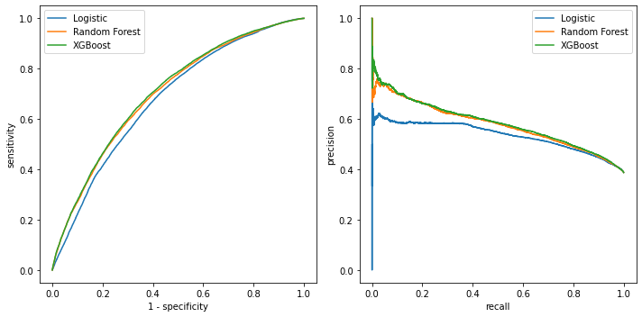

```python
plt.figure(figsize = (10, 5))

plt.subplot(1, 2, 1)
plt.plot(fpr_logistic, tpr_logistic, label = 'Logistic')
plt.plot(fpr_rf, tpr_rf, label = 'Random Forest')
plt.plot(fpr_xgb, tpr_xgb, label = 'XGBoost')
plt.legend()
plt.xlabel('1 - specificity'); plt.ylabel('sensitivity')

plt.subplot(1, 2 ,2)
plt.plot(recall_logistic, precision_logistic, label = 'Logistic')
plt.plot(recall_rf, precision_rf, label = 'Random Forest')
plt.plot(recall_xgb, precision_xgb, label = 'XGBoost')
plt.legend()
plt.xlabel('recall'); plt.ylabel('precision')

plt.tight_layout()
plt.show()
```